# Variables_TAE

Estefania Echeverry Franco

26 de marzo de 2021

```r
library(tidyverse)
library(dplyr)
library(ggplot2)
```

## Las variables de la base de datos

Las variables son:

**p8520s4:** Recolección de basuras. **p6081:** Padre vive en el Hogar **p8520s5:** Acueducto **P1896:** Nivel de Satisfaccción con los Ingresos **P6160:** Analfabetismo

Se cargan las base de datos

```r
setwd("~/Universidad Nacional/Noveno Semestre/Técnicas de Aprendizaje Estadístico")
datos_vivienda <- read.csv('Datos de la vivienda.csv', sep = ";", dec = ",")

compo_hogar <- read.csv("Caracteristicas y composicion del hogar.csv",sep=";", dec=",")

educacion <- read.csv("Educación.csv",sep = ";", dec = ",")
```

```r
colnames(datos_vivienda)[1] <-  "Directorio"
colnames(compo_hogar)[1] <- "Directorio"
colnames(educacion)[1] <- "Directorio"

datos_vivienda$Directorio <- as.factor(datos_vivienda$Directorio)
compo_hogar$DIRECTORIO <- as.factor(compo_hogar$Directorio)
educacion$DIRECTORIO <- as.factor(educacion$Directorio)
```

# Número de hijos

```r
#Se seleccionan las columnas directorio y P6051
directorio_P6051 <- compo_hogar %>% dplyr::select(Directorio,P6051)
#Se cuentan el numero de hijos por hogar
hijos_hogar <- directorio_P6051 %>% filter(P6051 == 3) %>% count(Directorio)
#Se renombra la columna
colnames(hijos_hogar)[2] <- "Hijos"
#head(hijos_hogar)
hijos_compo<- merge(x = hijos_hogar, y = compo_hogar, all= TRUE)
hijos_compo[is.na(hijos_compo$n),] <- 0
#sacando el Jefe del Hogar
jefe_compo <- compo_hogar %>% filter(P6051==1)
hijos_jefe<- merge(x = hijos_hogar, y = jefe_compo, all= TRUE)
hijos_jefe[is.na(hijos_jefe$n),] <- 0
hijos_jefex<- hijos_jefe[,1:2]
```

# Caracteristicas y Composición del Hogar

### Variable 6081 Padre vive en este Hogar ( Caracteristicas y Composición del Hogar)

*El padre de .. vive en este hogar*

14. El padre de ____ ¿vive en este hogar? 1 Sí 2 No 3 Fallecido

```r
resumen_nump <-tapply(hijos_jefe$Hijos, hijos_jefe$P6081, summary)
resumen_nump
```

```
## $`1`
##    Min. 1st Qu.  Median    Mean 3rd Qu.    Max.    NA's
##   1.000   1.000   2.000   1.956   2.000   7.000     247
##
## $`2`
##    Min. 1st Qu.  Median    Mean 3rd Qu.    Max.    NA's
##   1.000   1.000   2.000   1.941   2.000  13.000   14322
##
## $`3`
##    Min. 1st Qu.  Median    Mean 3rd Qu.    Max.    NA's
##   1.000   1.000   1.000   1.769   2.000  11.000   22055
```

```r
tablap <- do.call(rbind,resumen_nump)
tablap
```

```
##   Min. 1st Qu. Median     Mean 3rd Qu. Max.  NA's
## 1    1       1      2 1.955504       2    7   247
## 2    1       1      2 1.941382       2   13 14322
## 3    1       1      1 1.769237       2   11 22055
```

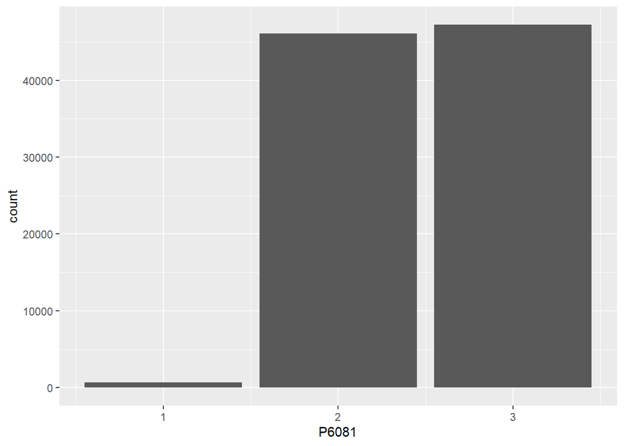

```r
ggplot(hijos_jefe, aes(x=P6081)) + geom_bar()
```

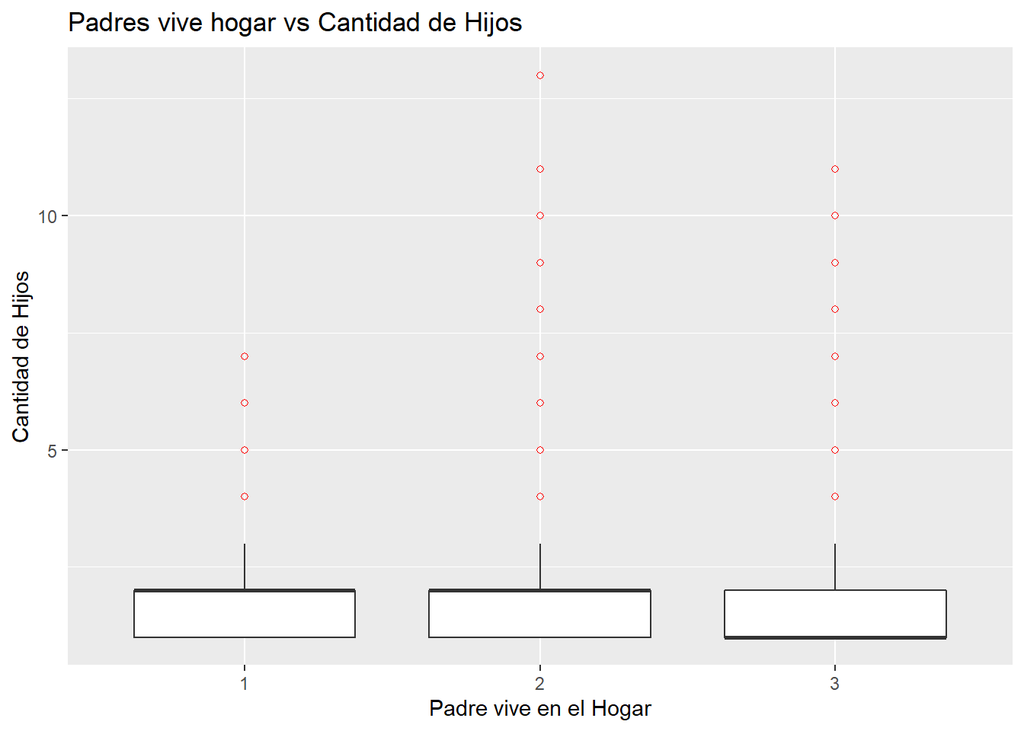

```r
ggplot(hijos_jefe, aes(x=factor(P6081), y=Hijos)) + geom_boxplot(outlier.colour = "red", outlier.shape = 1) + xlab("Padre vive en el Hogar")+ylab("Cantidad de Hijos")+ggtitle("Padres vive hogar vs Cantidad de Hijos")
```

Se nota que en la mayoria de lugares el padre no vive con ellos, o fallecio

## Variable P1896 Nivel de Satisfacción de los Ingresos ( Caracteristicas y Composición del Hogar)

**Nivel de Satisfacción de los Ingresos**

En general, qué tan satisfecho(a) se siente ... con su ingreso actualmente?

Las siguientes preguntas tratan sobre la satisfacción que Ud. siente, en una escala de 0 a 10. Donde 0 significa que se siente "totalmente insatisfecho" y 10 significa que se siente "totalmente satisfecho". 24. En general, qué tan satisfecho(a) se siente ... con su ingreso actualmente? 10 Totalmente satisfecho(a) 9 8 7 6 5 4 3 2 1 0 Totalmente insatisfecho(a)

```r
 hijos_jefena<- hijos_jefe[!is.na(hijos_jefe$P1896),]
resumen_numim <- tapply(hijos_jefena$Hijos, hijos_jefena$P1896, summary)
resumen_numim
```

```
## $`0`
##    Min. 1st Qu.  Median    Mean 3rd Qu.    Max.    NA's
##   1.000   1.000   2.000   1.907   2.000   8.000     712
##
## $`1`
##    Min. 1st Qu.  Median    Mean 3rd Qu.    Max.    NA's
##   1.000   1.000   2.000   1.938   2.000   7.000     413
##
## $`2`
##    Min. 1st Qu.  Median    Mean 3rd Qu.    Max.    NA's
##   1.000   1.000   2.000   1.982   3.000  13.000     982
##
## $`3`
##    Min. 1st Qu.  Median    Mean 3rd Qu.    Max.    NA's
##   1.000   1.000   2.000   1.942   2.000  10.000    1618
##
## $`4`
##    Min. 1st Qu.  Median    Mean 3rd Qu.    Max.    NA's
##   1.000   1.000   2.000   1.959   2.000  13.000    2130
##
## $`5`
##    Min. 1st Qu.  Median    Mean 3rd Qu.    Max.    NA's
##   1.000   1.000   2.000   1.908   2.000  11.000    4345
##
## $`6`
##    Min. 1st Qu.  Median    Mean 3rd Qu.    Max.    NA's
##   1.000   1.000   2.000   1.896   2.000   9.000    4313
##
## $`7`
##    Min. 1st Qu.  Median    Mean 3rd Qu.    Max.    NA's
##   1.000   1.000   2.000   1.858   2.000  13.000    5701
##
## $`8`
##    Min. 1st Qu.  Median    Mean 3rd Qu.    Max.    NA's
##   1.000   1.000   2.000   1.808   2.000   8.000    6557
##
## $`9`
##    Min. 1st Qu.  Median    Mean 3rd Qu.    Max.    NA's
##   1.000   1.000   2.000   1.791   2.000   8.000    2873
##
## $`10`
##    Min. 1st Qu.  Median    Mean 3rd Qu.    Max.    NA's
##   1.000   1.000   2.000   1.775   2.000   8.000    4457
##
## $`99`
##    Min. 1st Qu.  Median    Mean 3rd Qu.    Max.    NA's
##   1.000   1.000   2.000   1.924   2.000  10.000    2516
```

```r
tablaim <- do.call(rbind,resumen_numim)
tablaim
```

```
##    Min. 1st Qu. Median     Mean 3rd Qu. Max. NA's
## 0     1       1      2 1.907451       2    8  712
## 1     1       1      2 1.938346       2    7  413
## 2     1       1      2 1.982131       3   13  982
## 3     1       1      2 1.942046       2   10 1618
## 4     1       1      2 1.958612       2   13 2130
## 5     1       1      2 1.908287       2   11 4345
## 6     1       1      2 1.896157       2    9 4313
## 7     1       1      2 1.857691       2   13 5701
## 8     1       1      2 1.807819       2    8 6557
## 9     1       1      2 1.791385       2    8 2873
## 10    1       1      2 1.774952       2    8 4457
## 99    1       1      2 1.924311       2   10 2516
```

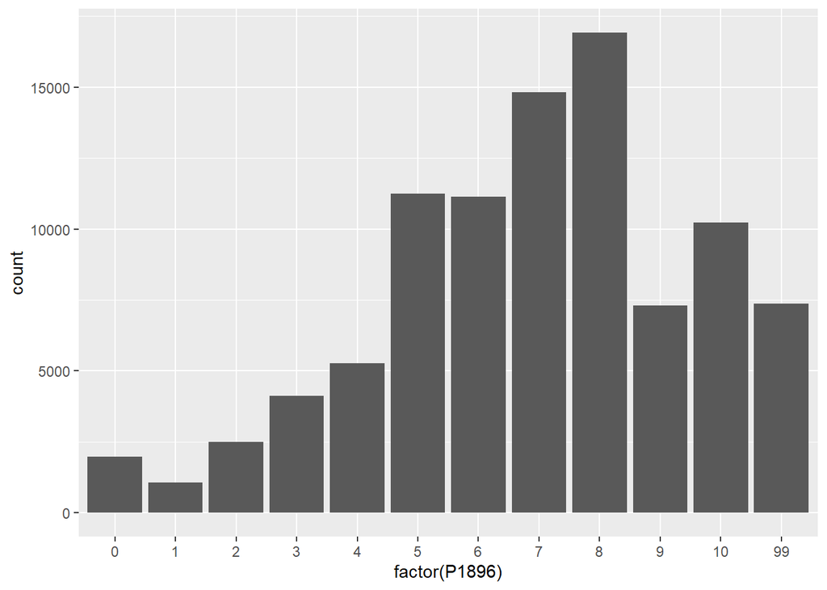

```r
ggplot(hijos_jefena, aes(x=factor(P1896))) + geom_bar()
```

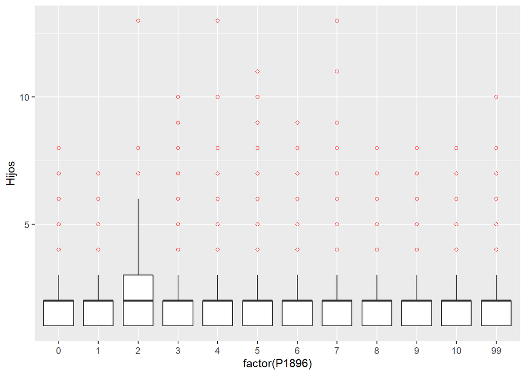

```r
ggplot(hijos_jefena, aes(x = factor(P1896), y = Hijos)) + geom_boxplot(outlier.colour = "red", outlier.shape = 1)
```

## Variable P8520S4 (Recolección de Basura) Datos de la Vivienda

**Recolección de basuras**

5. ¿Con cuáles de los siguientes servicios públicos, privados o comunales cuenta la vivienda?
6. Recolección de basuras 1 Sí 2 No

```r
datos_vivienda_re <- datos_vivienda %>% dplyr::select(Directorio, P8520S4)
hijos_jefe <- merge(hijos_jefe, datos_vivienda_re, all=TRUE)
```

```r
resumenes_num <- tapply(hijos_jefe$Hijos , hijos_jefe$P8520S4,summary)
```

```r
tablar <- do.call (rbind, resumenes_num)
tablar
```

```
##   Min. 1st Qu. Median     Mean 3rd Qu. Max.  NA's
## 1    1       1      2 1.786131       2   13 22395
## 2    1       1      2 2.014826       3   10 14229
```

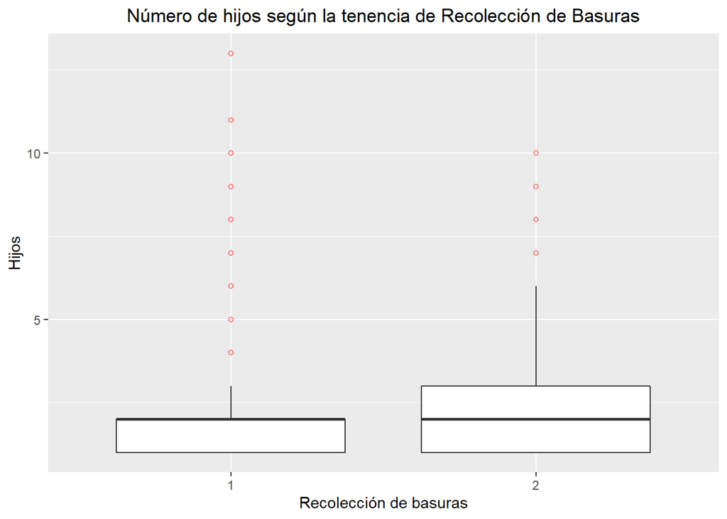

```r
ggplot(hijos_jefe, aes(x = as.factor(P8520S4), y = Hijos)) + geom_boxplot(outlier.colour="red", outlier.shape = 1) +
    xlab("Recolección de basuras") +
    ggtitle("Número de hijos según la tenencia de Recolección de Basuras")+
    theme(plot.title = element_text(hjust = 0.5))
```

```r
hijos_jefe$P8520S4 <- as.factor(hijos_jefe$P8520S4)

modn <- lm(Hijos ~ P8520S4 , data=hijos_jefe)
summary(modn)
```

```
##
## Call:
## lm(formula = Hijos ~ P8520S4, data = hijos_jefe)
##
## Residuals:
##     Min      1Q  Median      3Q     Max
## -1.0148 -0.7861 -0.0148  0.2139 11.2139
##
## Coefficients:
##             Estimate Std. Error t value Pr(>|t|)
## (Intercept) 1.786131   0.005416  329.78   <2e-16 ***
## P8520S42    0.228694   0.009166   24.95   <2e-16 ***
## ---
## Signif. codes:  0 '***' 0.001 '**' 0.01 '*' 0.05 '.' 0.1 ' ' 1
##
## Residual standard error: 1.047 on 57367 degrees of freedom
##   (36624 observations deleted due to missingness)
## Multiple R-squared:  0.01074,    Adjusted R-squared:  0.01072
## F-statistic: 622.6 on 1 and 57367 DF,  p-value: < 2.2e-16
```

## variable P8520S5 (Acueducto) Datos de la Vivienda

** Acueducto**

```
5. ¿Con cuáles de los siguientes servicios públicos, privados o comunales cuenta la vivienda?
```

2. Acueducto 1 Sí 2 No

```r
datos_vivienda_acu <- datos_vivienda %>% dplyr::select(Directorio, P8520S5)
hijos_jefe <- merge(hijos_jefe, datos_vivienda_acu, all=TRUE)
```

```r
resumenes_num_acu<- tapply(hijos_jefe$Hijos , hijos_jefe$P8520S5,summary)
resumenes_num_acu
```

```
## $`1`
##    Min. 1st Qu.  Median    Mean 3rd Qu.    Max.    NA's
##   1.000   1.000   2.000   1.799   2.000  13.000   25463
##
## $`2`
##    Min. 1st Qu.  Median    Mean 3rd Qu.    Max.    NA's
##   1.000   1.000   2.000   2.042   3.000  10.000   11161
```

```r
tablacu <- do.call (rbind, resumenes_num_acu)
tablacu
```

```
##   Min. 1st Qu. Median     Mean 3rd Qu. Max.  NA's
## 1    1       1      2 1.799047       2   13 25463
## 2    1       1      2 2.041854       3   10 11161
```

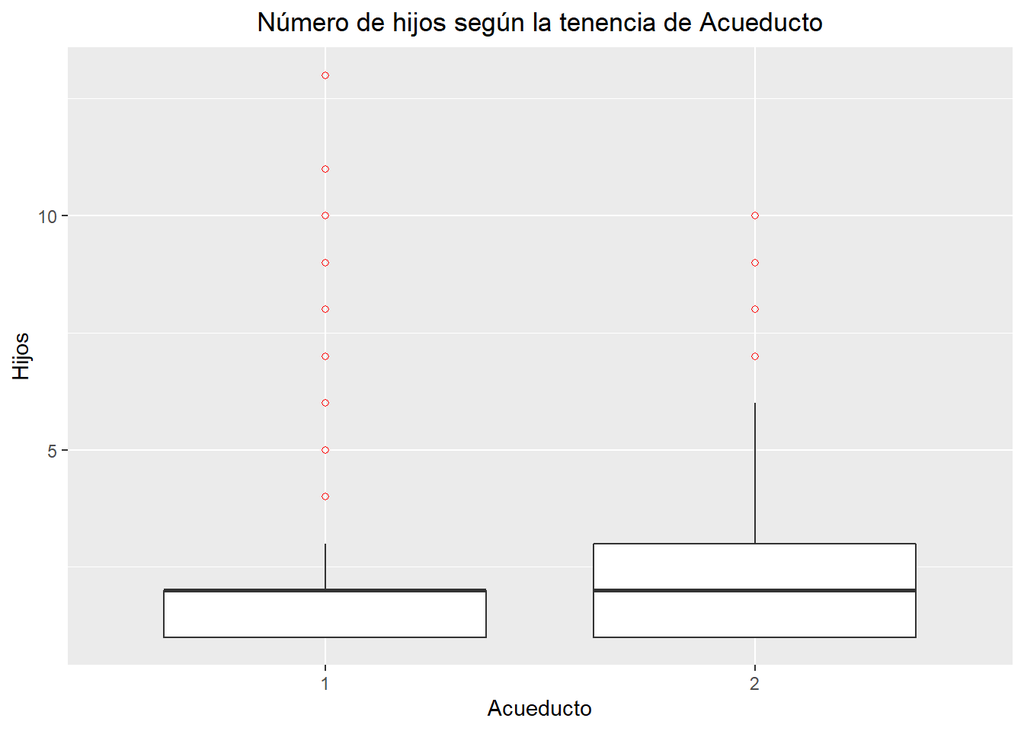

```r
ggplot(hijos_jefe, aes(x = as.factor(P8520S5), y = Hijos)) + geom_boxplot(outlier.colour ="red", outlier.shape = 1) +
    xlab("Acueducto") +
    ggtitle("Número de hijos según la tenencia de Acueducto")+
    theme(plot.title = element_text(hjust = 0.5))
```

```r
hijos_jefe$P8520S5 <- as.factor(hijos_jefe$P8520S5)
modnacu <- lm(Hijos ~ P8520S5 , data=hijos_jefe)
summary(modnacu)
```

```
##
## Call:
## lm(formula = Hijos ~ P8520S5, data = hijos_jefe)
##
## Residuals:
##     Min      1Q  Median      3Q     Max
## -1.0419 -0.7990 -0.0419  0.2010 11.2010
##
## Coefficients:
##             Estimate Std. Error t value Pr(>|t|)
## (Intercept) 1.799047   0.005134  350.39   <2e-16 ***
## P8520S52    0.242807   0.009778   24.83   <2e-16 ***
## ---
## Signif. codes:  0 '***' 0.001 '**' 0.01 '*' 0.05 '.' 0.1 ' ' 1
##
## Residual standard error: 1.047 on 57367 degrees of freedom
##   (36624 observations deleted due to missingness)
## Multiple R-squared:  0.01063,    Adjusted R-squared:  0.01062
## F-statistic: 616.6 on 1 and 57367 DF,  p-value: < 2.2e-16
```

```r
modn2 <- lm(Hijos ~ P8520S4 + P8520S5 , data=hijos_jefe)
summary(modn2)
```

```
##
## Call:
## lm(formula = Hijos ~ P8520S4 + P8520S5, data = hijos_jefe)
##
## Residuals:
##     Min      1Q  Median      3Q     Max
## -1.0767 -0.7706 -0.0767  0.2294 11.2294
##
## Coefficients:
##             Estimate Std. Error t value Pr(>|t|)
## (Intercept) 1.770640   0.005528  320.31   <2e-16 ***
## P8520S42    0.149300   0.010876   13.73   <2e-16 ***
## P8520S52    0.156744   0.011602   13.51   <2e-16 ***
## ---
## Signif. codes:  0 '***' 0.001 '**' 0.01 '*' 0.05 '.' 0.1 ' ' 1
##
## Residual standard error: 1.045 on 57366 degrees of freedom
##   (36624 observations deleted due to missingness)
## Multiple R-squared:  0.01387,    Adjusted R-squared:  0.01384
## F-statistic: 403.5 on 2 and 57366 DF,  p-value: < 2.2e-16
```

## Variable P6160 (Analfabetismo) Educación

** Analfabetismo**

¿Sabe leer y escribir?

1 Sí 2 No

```r
educacion_alf <- educacion %>% dplyr::select(Directorio, P6160)
hijos_jefe <- merge(hijos_jefe, educacion_alf, all=TRUE)
```

```r
resumenes_num_aLf<- tapply(hijos_jefe$Hijos , hijos_jefe$P6160,summary)
resumenes_num_aLf
```

```
## $`1`
##    Min. 1st Qu.  Median    Mean 3rd Qu.    Max.    NA's
##    1.00    1.00    2.00    2.14    3.00   13.00   54959
##
## $`2`
##    Min. 1st Qu.  Median    Mean 3rd Qu.    Max.    NA's
##   1.000   1.000   2.000   2.324   3.000  13.000    7350
```

```r
tablalf <- do.call (rbind, resumenes_num_aLf)
tablalf
```

```
##   Min. 1st Qu. Median     Mean 3rd Qu. Max.  NA's
## 1    1       1      2 2.141383       3   13 54959
## 2    1       1      2 2.324260       3   13  7350
```

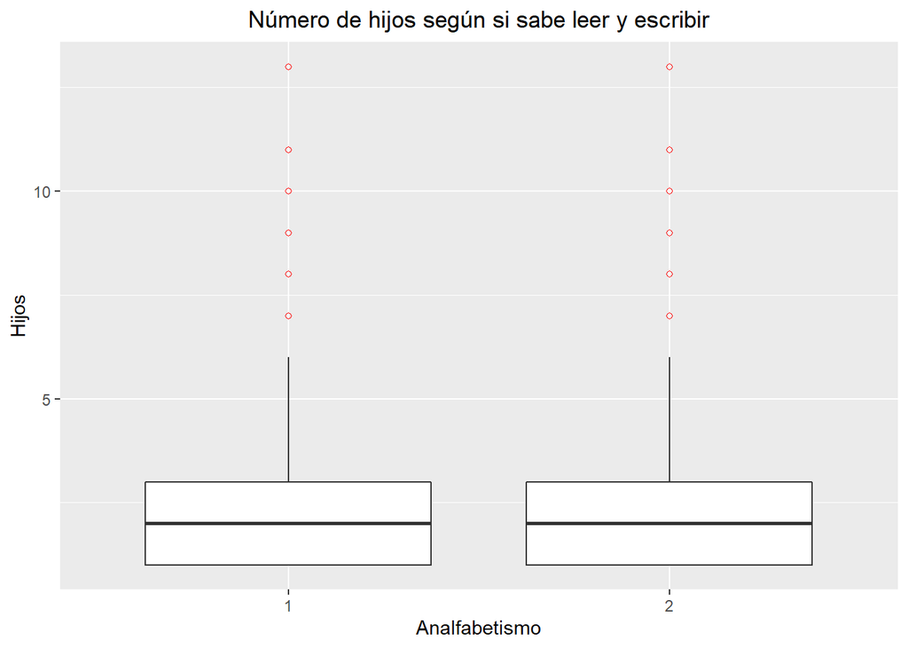

```r
ggplot(hijos_jefe, aes(x = as.factor(P6160), y = Hijos)) + geom_boxplot(outlier.colour="red", outlier.shape = 1) +
    xlab("Analfabetismo") +
    ggtitle("Número de hijos según si sabe leer y escribir")+
    theme(plot.title = element_text(hjust = 0.5))
```

#Base de Datos Salud

```r
salud <- read.csv("Salud.csv",sep = ";", dec = ",")
```

```r
colnames(salud)[1] <- "Directorio"
salud$Directorio <- as.factor(salud$Directorio)
hijos_jefe <- merge(hijos_jefe, salud, all=TRUE)
```

# Salud

## Variable P6090 "Afiliado a EPS" (Salud)

¿ _____ está afiliado(a) (cotizante o beneficiario(a)) a alguna entidad de seguridad social en salud? (Entidad Promotora de Salud - EPS o Entidad Promotora de Salud Subsidiada -EPS-S )

1. ¿ ______ está afiliado (a), es cotizante o es beneficiario (a) de alguna entidad de seguridad social en salud? (ver nota) (Entidad promotora de salud [EPS] o entidad promotora de salud subsidiada EPS-S) 1 Sí 2 No 9 No sabe, no informa

```r
resumenes_num_EPS<- tapply(hijos_jefe$Hijos , hijos_jefe$P6090,summary)
resumenes_num_EPS
```

```
## $`1`
##    Min. 1st Qu.  Median    Mean 3rd Qu.    Max.    NA's
##    1.00    1.00    2.00    2.14    3.00   13.00  240560
##
## $`2`
##    Min. 1st Qu.  Median    Mean 3rd Qu.    Max.    NA's
##   1.000   1.000   2.000   2.374   3.000  13.000   16753
##
## $`9`
##    Min. 1st Qu.  Median    Mean 3rd Qu.    Max.    NA's
##   1.000   1.000   2.000   2.062   3.000   6.000     561
```

```r
tablaEPS <- do.call (rbind, resumenes_num_EPS)
tablaEPS
```

```
##   Min. 1st Qu. Median     Mean 3rd Qu. Max.   NA's
## 1    1       1      2 2.142708       3   13 240560
## 2    1       1      2 2.373976       3   13  16753
## 9    1       1      2 2.061576       3    6    561
```

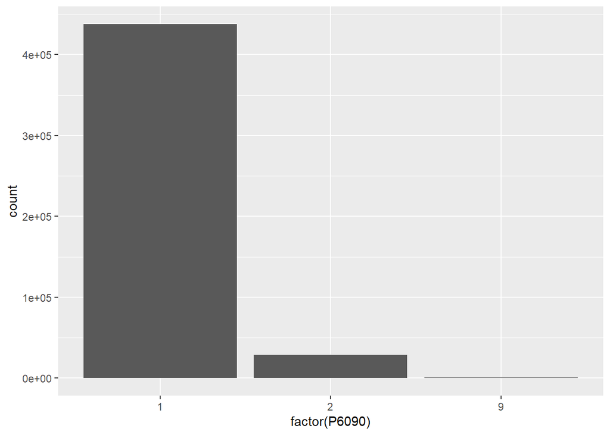

```r
ggplot(hijos_jefe, aes(x=factor(P6090))) + geom_bar()
```

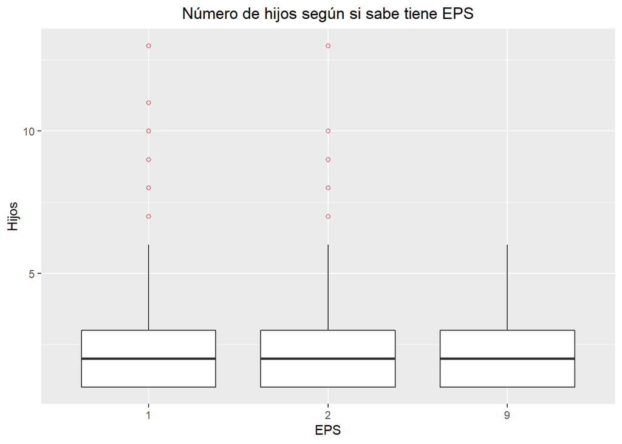

```r
ggplot(hijos_jefe, aes(x = as.factor(P6090), y = Hijos)) + geom_boxplot(outlier.colour="red", outlier.shape = 1) +
    xlab("EPS") +
    ggtitle("Número de hijos según si sabe tiene EPS")+
    theme(plot.title = element_text(hjust = 0.5))
```

```r
hijos_jefe$P6090 <- as.factor(hijos_jefe$P6090)
modeps <- lm(Hijos ~ P6090 , data =hijos_jefe)
summary(modeps)
```

```
##
## Call:
## lm(formula = Hijos ~ P6090, data = hijos_jefe)
##
## Residuals:
##     Min      1Q  Median      3Q     Max
## -1.3740 -1.1427 -0.1427  0.8573 10.8573
##
## Coefficients:
##              Estimate Std. Error t value Pr(>|t|)
## (Intercept)  2.142708   0.002811 762.292   <2e-16 ***
## P60902       0.231268   0.011753  19.678   <2e-16 ***
## P60909      -0.081131   0.061995  -1.309    0.191
## ---
## Signif. codes:  0 '***' 0.001 '**' 0.01 '*' 0.05 '.' 0.1 ' ' 1
##
## Residual standard error: 1.248 on 209449 degrees of freedom
##   (257874 observations deleted due to missingness)
## Multiple R-squared:  0.001856,   Adjusted R-squared:  0.001847
## F-statistic: 194.8 on 2 and 209449 DF,  p-value: < 2.2e-16
```

# Variable P6100 (Regimen de Seguridad)

¿A cual de los siguientes regímenes de seguridad social en salud está afiliado:

3. ¿A cuál de los siguientes regímenes de seguridad social en salud está afiliado? 1 Contributivo (eps) 2 Especial (fuerzas armadas, ecopetrol, universidades públicas, magisterio) 3 Subsidiado (eps-s) 9 No sabe, no informa

```r
resumenes_num_regi<- tapply(hijos_jefe$Hijos , hijos_jefe$P6100,summary)
resumenes_num_regi
```

```
## $`1`
##    Min. 1st Qu.  Median    Mean 3rd Qu.    Max.    NA's
##    1.00    1.00    2.00    1.89    2.00    9.00   66740
##
## $`2`
##    Min. 1st Qu.  Median    Mean 3rd Qu.    Max.    NA's
##    1.00    1.00    2.00    1.87    2.00    6.00    5292
##
## $`3`
##    Min. 1st Qu.  Median    Mean 3rd Qu.    Max.    NA's
##    1.00    1.00    2.00    2.27    3.00   13.00  167955
##
## $`9`
##    Min. 1st Qu.  Median    Mean 3rd Qu.    Max.    NA's
##   1.000   1.000   2.000   2.181   3.000   5.000     573
```

```r
tablaregi <- do.call (rbind, resumenes_num_regi)
tablaregi
```

```
##   Min. 1st Qu. Median     Mean 3rd Qu. Max.   NA's
## 1    1       1      2 1.889203       2    9  66740
## 2    1       1      2 1.869922       2    6   5292
## 3    1       1      2 2.269461       3   13 167955
## 9    1       1      2 2.181176       3    5    573
```

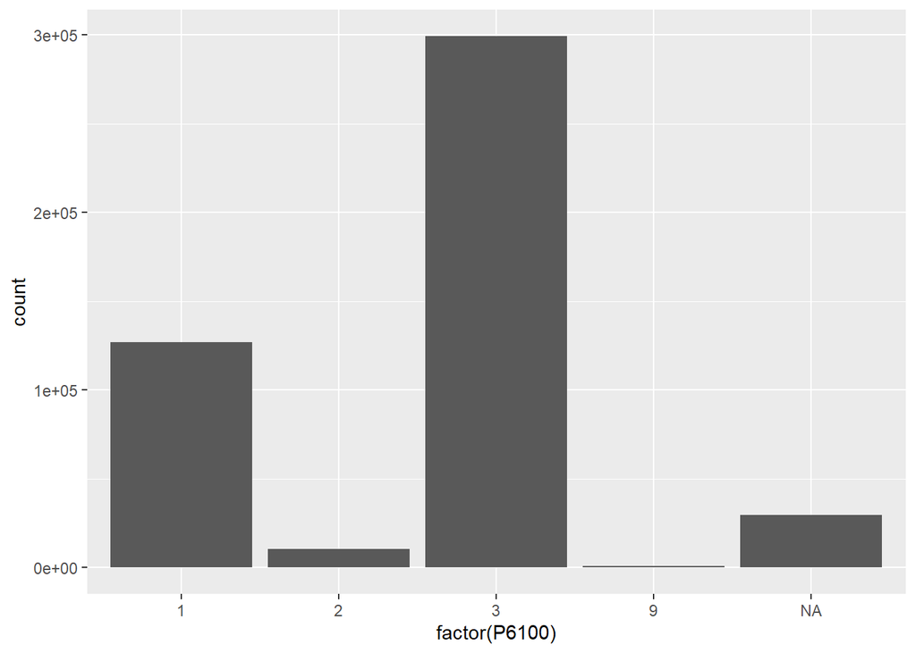

```r
ggplot(hijos_jefe, aes(x=factor(P6100))) + geom_bar()
```

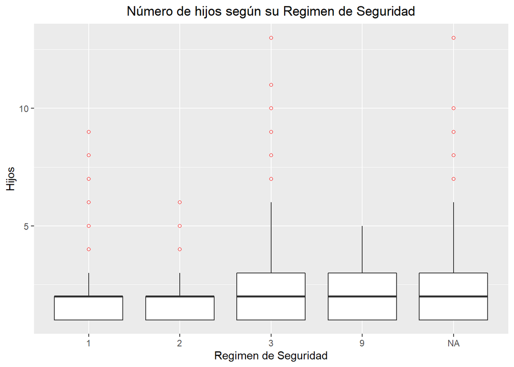

```r
ggplot(hijos_jefe, aes(x = as.factor(P6100), y = Hijos)) + geom_boxplot(outlier.colour="red", outlier.shape = 1) +
    xlab("Regimen de Seguridad") +
    ggtitle("Número de hijos según su Regimen de Seguridad")+
    theme(plot.title = element_text(hjust = 0.5))
```

```r
hijos_jefe$P6100 <- as.factor(hijos_jefe$P6100)
moders<- lm(Hijos ~ P6100 , data =hijos_jefe)
summary(moders)
```

```
##
## Call:
## lm(formula = Hijos ~ P6100, data = hijos_jefe)
##
## Residuals:
##     Min      1Q  Median      3Q     Max
## -1.2695 -0.8892 -0.2695  0.7305 10.7305
##
## Coefficients:
##              Estimate Std. Error t value Pr(>|t|)
## (Intercept)  1.889203   0.004947 381.909  < 2e-16 ***
## P61002      -0.019281   0.017671  -1.091    0.275
## P61003       0.380259   0.005974  63.650  < 2e-16 ***
## P61009       0.291974   0.059090   4.941 7.77e-07 ***
## ---
## Signif. codes:  0 '***' 0.001 '**' 0.01 '*' 0.05 '.' 0.1 ' ' 1
##
## Residual standard error: 1.214 on 197084 degrees of freedom
##   (270238 observations deleted due to missingness)
## Multiple R-squared:  0.02144,    Adjusted R-squared:  0.02142
## F-statistic:  1439 on 3 and 197084 DF,  p-value: < 2.2e-16
```

# Variable 6127 (Estado de Salud)

El estado de salud de .. en general es

10. El estado de salud de ___ en general, es: 1 Muy bueno 2 Bueno 3 Regular 4 Malo

```r
resumenes_num_est<- tapply(hijos_jefe$Hijos , hijos_jefe$P6127,summary)
resumenes_num_est
```

```
## $`1`
##    Min. 1st Qu.  Median    Mean 3rd Qu.    Max.    NA's
##    1.00    1.00    2.00    2.07    3.00    8.00   24125
##
## $`2`
##    Min. 1st Qu.  Median    Mean 3rd Qu.    Max.    NA's
##     1.0     1.0     2.0     2.2     3.0    13.0  190969
##
## $`3`
##    Min. 1st Qu.  Median    Mean 3rd Qu.    Max.    NA's
##    1.00    1.00    2.00    2.05    3.00   10.00   39951
##
## $`4`
##    Min. 1st Qu.  Median    Mean 3rd Qu.    Max.    NA's
##   1.000   1.000   2.000   1.879   2.000   6.000    2829
```

```r
tablarest <- do.call (rbind, resumenes_num_est)
tablarest
```

```
##   Min. 1st Qu. Median     Mean 3rd Qu. Max.   NA's
## 1    1       1      2 2.069769       3    8  24125
## 2    1       1      2 2.202776       3   13 190969
## 3    1       1      2 2.052945       3   10  39951
## 4    1       1      2 1.878920       2    6   2829
```

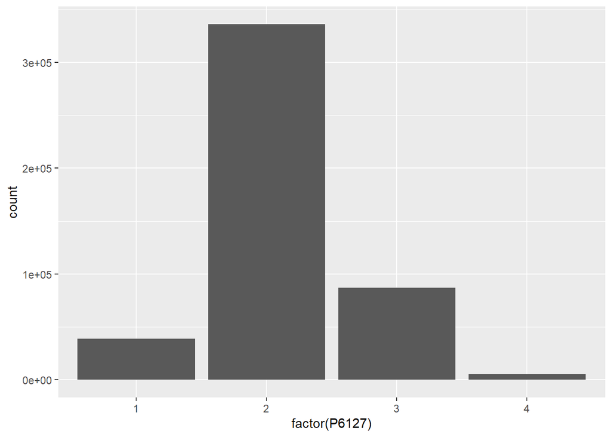

```r
ggplot(hijos_jefe, aes(x=factor(P6127))) + geom_bar()
```

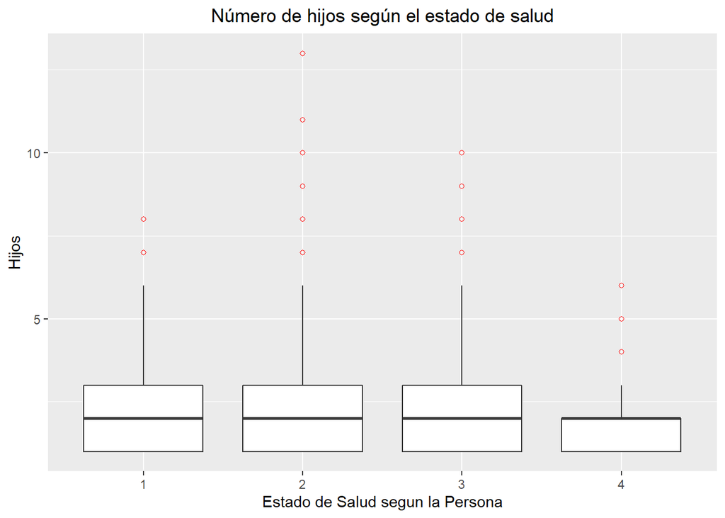

```r
ggplot(hijos_jefe, aes(x = as.factor(P6127), y = Hijos)) + geom_boxplot(outlier.colour="red", outlier.shape = 1) +
  xlab("Estado de Salud segun la Persona") +
  ggtitle("Número de hijos según el estado de salud")+
  theme(plot.title = element_text(hjust = 0.5))
```

```r
hijos_jefe$P6127 <- as.factor(hijos_jefe$P6127)
modees<- lm(Hijos ~ P6127 , data =hijos_jefe)
summary(modees)
```

```
##
## Call:
## lm(formula = Hijos ~ P6127, data = hijos_jefe)
##
## Residuals:
##     Min      1Q  Median      3Q     Max
## -1.2028 -1.0698 -0.2028  0.7972 10.7972
##
## Coefficients:
##             Estimate Std. Error t value Pr(>|t|)
## (Intercept)  2.06977    0.01020 202.859  < 2e-16 ***
## P61272       0.13301    0.01072  12.412  < 2e-16 ***
## P61273      -0.01682    0.01171  -1.437    0.151
## P61274      -0.19085    0.02686  -7.106  1.2e-12 ***
## ---
## Signif. codes:  0 '***' 0.001 '**' 0.01 '*' 0.05 '.' 0.1 ' ' 1
##
## Residual standard error: 1.247 on 209448 degrees of freedom
##   (257874 observations deleted due to missingness)
## Multiple R-squared:  0.003431,   Adjusted R-squared:  0.003417
## F-statistic: 240.4 on 3 and 209448 DF,  p-value: < 2.2e-16
```

# Variable 5672 (Estado de Embarazo)

¿ _____ está embarazada actualmente o ha tenido hijos?

44. ¿_____ está embarazada actualmente o ha tenido hijos?
45. Sí
46. No

```r
resumenes_num_emb<- tapply(hijos_jefe$Hijos , hijos_jefe$P5672,summary)
resumenes_num_emb
```

```
## $`1`
##    Min. 1st Qu.  Median    Mean 3rd Qu.    Max.    NA's
##    1.00    1.00    2.00    2.33    3.00   13.00   37352
##
## $`2`
##    Min. 1st Qu.  Median    Mean 3rd Qu.    Max.    NA's
##    1.00    1.00    2.00    2.18    3.00   10.00   37970
```

```r
tablaremb <- do.call (rbind, resumenes_num_emb)
tablaremb
```

```
##   Min. 1st Qu. Median     Mean 3rd Qu. Max.  NA's
## 1    1       1      2 2.330493       3   13 37352
## 2    1       1      2 2.184742       3   10 37970
```

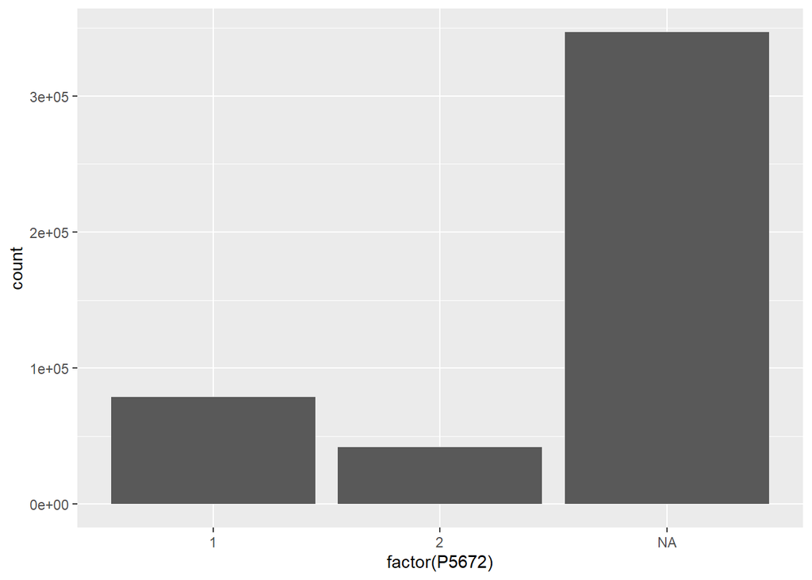

```r
ggplot(hijos_jefe, aes(x=factor(P5672))) + geom_bar()
```

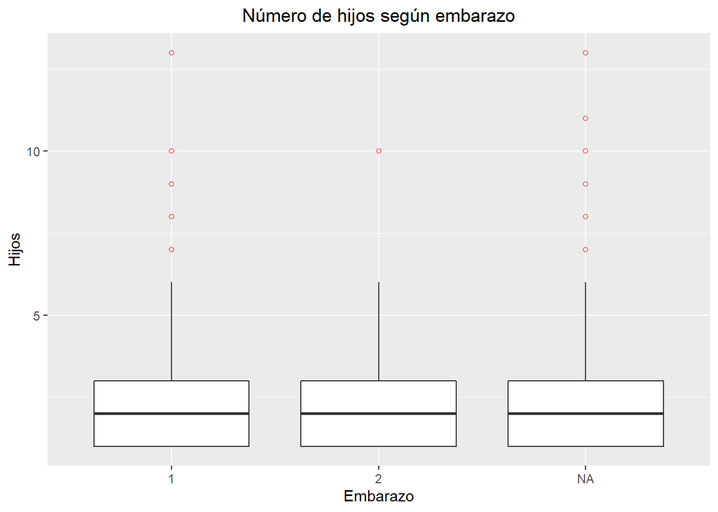

```r
ggplot(hijos_jefe, aes(x = as.factor(P5672), y = Hijos)) + geom_boxplot(outlier.colour="red", outlier.shape = 1) +
    xlab("Embarazo") +
    ggtitle("Número de hijos según embarazo")+
    theme(plot.title = element_text(hjust = 0.5))
```